# Setup R and RStudio on Desktop

## 1. Download materials from the Github page

Visit GitHub repository: https://github.com/analeigh-gui/single-cell-boot-camp

Click on **Code**.

Select **Download ZIP** in the drop down menu (Example below).

[figure not shown]

Unzip the downloaded file.

If you do not have R and RStudio on your desktop, please follow the next section to set up R and RStudio.

## 2. Set up R and RStudio

Here are the steps to set up the most up-to-date R and RStudio on your desktop:

1. Go to the RStudio website at https://posit.co/download/rstudio-desktop/.
2. Download and install R.
3. Download the RStudio Desktop for your operating system (Windows, Mac, or Linux) by clicking on the appropriate link.
4. Once the download is complete, double-click the downloaded file to start the installation process.
5. Follow the installation instructions provided by the RStudio installer.
6. After RStudio is installed, open the RStudio application.
7. RStudio should automatically detect an existing installation of R on your system. If not, you may be prompted to select the path to the R executable file.
8. Once R is detected or selected, RStudio will launch and you will see the RStudio IDE (Integrated Development Environment) with the R console.
9. You are now ready to start using R and RStudio on your desktop.

Now that you have R and RStudio set up, you can follow the next section to install the R packages.

## 3. Install R packages

**ONLY for windows machines**: If you are working on Windows, please first download and install RTools from https://cran.r-project.org/bin/windows/Rtools/.

Mac users can proceed directly.

1. Open RStudio.

Execute the following commands **one by one** in the **Console**. Wait for each installation to finish before moving on to the next command.

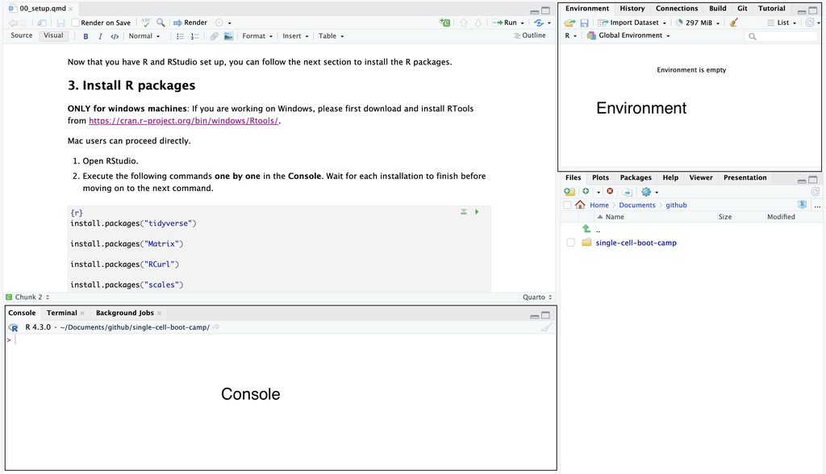

```r
install.packages("tidyverse")
install.packages("Matrix")
install.packages("RCurl")
install.packages("scales")
install.packages("data.table")
install.packages("readxl")
install.packages("BiocManager")
install.packages("ggpubr")
install.packages("Seurat")
BiocManager::install("ensembldb")
BiocManager::install("org.Hs.eg.db")
BiocManager::install("clusterProfiler")
BiocManager::install("AnnotationHub")
BiocManager::install("AnnotationDbi")
BiocManager::install("biomaRt")
BiocManager::install("enrichplot")
BiocManager::install("HGNChelper")
```

Now that you have R, RStudio and R packages set up, you can follow the next chapter to practice on the materials.

To start practicing, go to the download folder, and double click **single-cell-boot-camp.Rproj**.

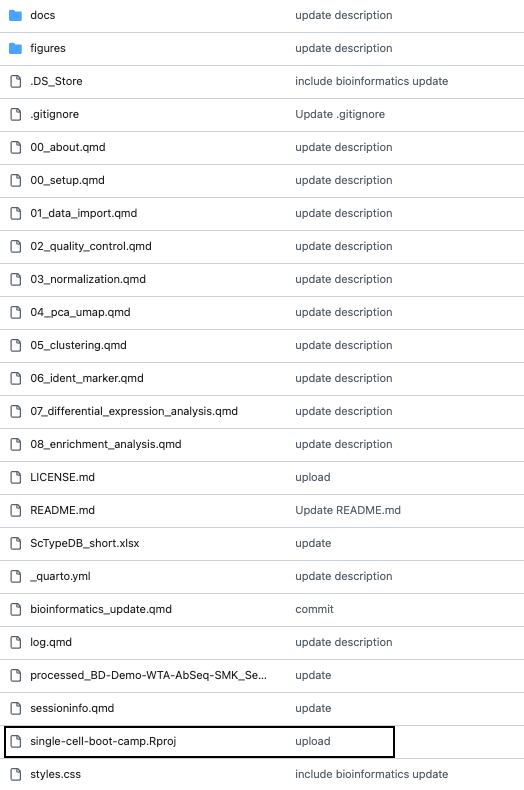

## 4. Reporting bugs

To report any bugs, please create an issue in the following GitHub repository: https://github.com/analeigh-gui/single-cell-boot-camp.